# Connessioni pericolose: analisi delle interazioni della Mafia Siciliana

10 febbraio 2025

## La Mafia Siciliana

Operazione Montagna (2007): indagine su due clan mafiosi, la “famiglia Mistretta” e il “clan Batanesi”, infiltrati in attività economiche (grandi opere infrastrutturali).

Obiettivo: Analizzare le interazioni mafiose attraverso la Network Analysis in R

Caratteristiche della rete mafiosa:

- Durata intergenerazionale
- Legami stretti tra affiliati
- Attività illegali per perseguire obiettivi specifici

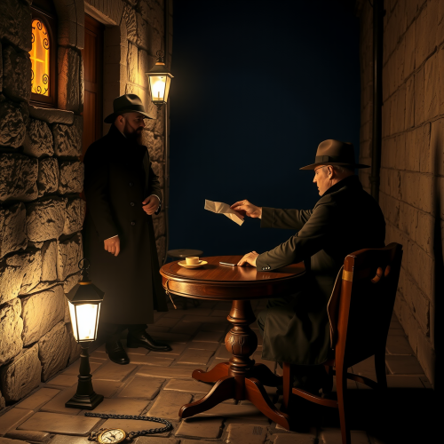

Generated with DALL-E

## Il dataset: reti di incontri e comunicazioni telefoniche

Dati disponibili su [Zenodo](https://zenodo.org/records/3938818#.YW4WLhxxWUl).

Dataset contenente 3 CSV:

- **Roles**: Ruoli degli indagati e relazioni con altri sospettati
- **Meetings**: Incontri fisici tra i sospettati (documentati tramite appostamenti della polizia)
- **Phone Calls**: Telefonate intercettate tra i sospettati

Tipologia di reti:

- Indirette e pesate (frequenza delle interazioni come peso)
- Nodi anonimi

Le reti risultanti per gli incontri fisici e le telefonate sono queste:

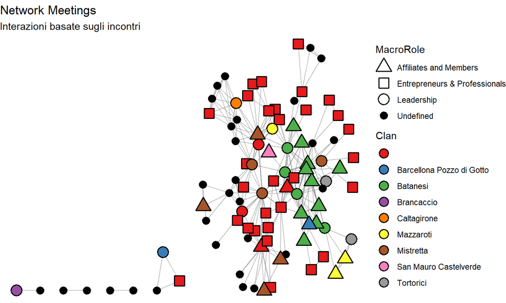

La rete degli incontri con 94 nodi e 284 archi.

- Una componente connessa gigante e piccole componenti isolate, probabilmente a causa di dati mancanti
- La famiglia Batanesi (verde) è numerosa e compatta, mentre la famiglia Mistretta è più dispersa e meno influente
- Significativa la presenza di imprenditori e professionisti che agiscono come intermediari tra il mondo legale e illegale, supportando l’organizzazione

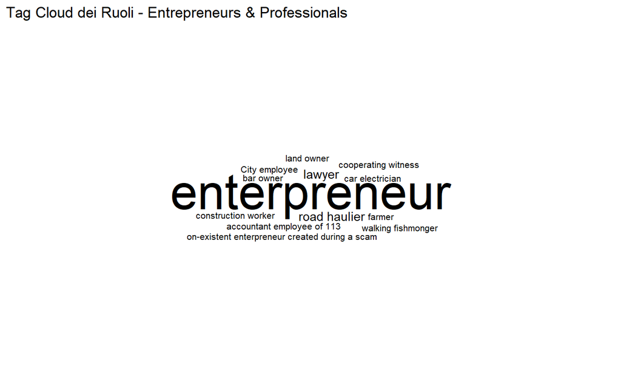

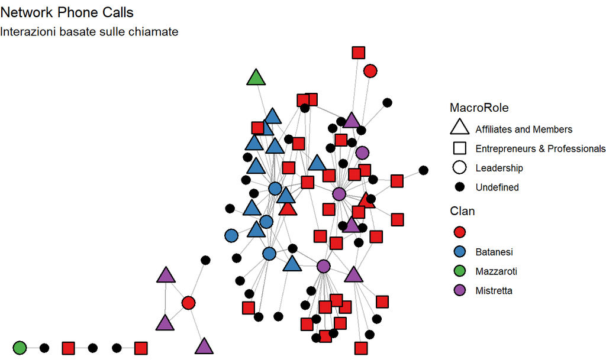

La rete delle telefonate con 94 nodi e 149 archi.

- Meno densa rispetto agli incontri, coinvolge meno famiglie
- Anche qui, la famiglia Batanesi (blu) ha interazioni più concentrate rispetto alla famiglia Mistretta

## Chi sono gli individui che hanno avuto più incontri o telefonate nella rete?

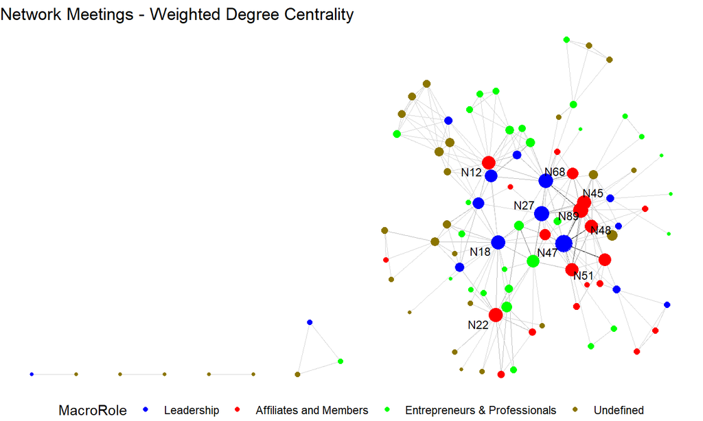

```
## # A tibble: 10 × 4
##    name  Role                            MacroRole              weighted_degree
##    <chr> <chr>                           <chr>                            <dbl>
##  1 N47   deputy boss family ''Batanesi'' Leadership                          65
##  2 N89   member family ''Batanesi''      Affiliates and Members              46
##  3 N27   executive family ''Batanesi''   Leadership                          44
##  4 N68   executive family ''Batanesi''   Leadership                          42
##  5 N22   Pharmacist-member               Affiliates and Members              37
##  6 N45   member family ''Batanesi''      Affiliates and Members              37
##  7 N18   executive family ''Mistretta''  Leadership                          36
##  8 N12   member family ''Mistretta''     Affiliates and Members              35
##  9 N51   member family ''Batanesi''      Affiliates and Members              32
## 10 N48   member family ''Batanesi''      Affiliates and Members              31
```

- Il Deputy Boss della famiglia Batanesi è il nodo più centrale
- La famiglia Batanesi ha più membri con ruoli influenti e più connessioni
- La famiglia Mistretta sembra meno connessa e meno influente nella rete
- Il farmacista affiliato (N22) potrebbe avere un ruolo chiave come intermediario

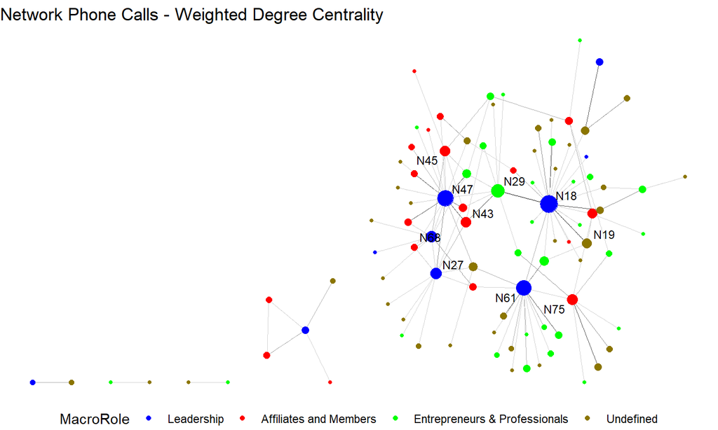

```
## # A tibble: 10 × 4
##    name  Role                              MacroRole             weighted_degree
##    <chr> <chr>                             <chr>                           <dbl>
##  1 N18   "executive family ''Mistretta''"  Leadership                         67
##  2 N47   "deputy boss family ''Batanesi''" Leadership                         55
##  3 N61   "executive family ''Mistretta''"  Leadership                         46
##  4 N29   "enterpreneur"                    Entrepreneurs & Prof…              32
##  5 N27   "executive family ''Batanesi''"   Leadership                         20
##  6 N68   "executive family ''Batanesi''"   Leadership                         20
##  7 N75   "member family ''Mistretta''"     Affiliates and Membe…              17
##  8 N43   "intermediator"                   Affiliates and Membe…              15
##  9 N45   "member family ''Batanesi''"      Affiliates and Membe…              15
## 10 N19   ""                                Undefined                          13
```

- La famiglia Mistretta ha la leadership più connessa, superando il Deputy Boss dei Batanesi
- Imprenditori e intermediari emergono con ruoli chiave, come N29 e N43
- Il potere appare più distribuito tra diverse figure, anziché concentrato in una sola famiglia

Sembra quindi che la famiglia Mistretta prediliga le telefonate, mentre la famiglia Batanesi preferisca incontri segreti di persona.

## Esistono pochi nodi altamente connessi o il peso è distribuito in modo omogeneo?

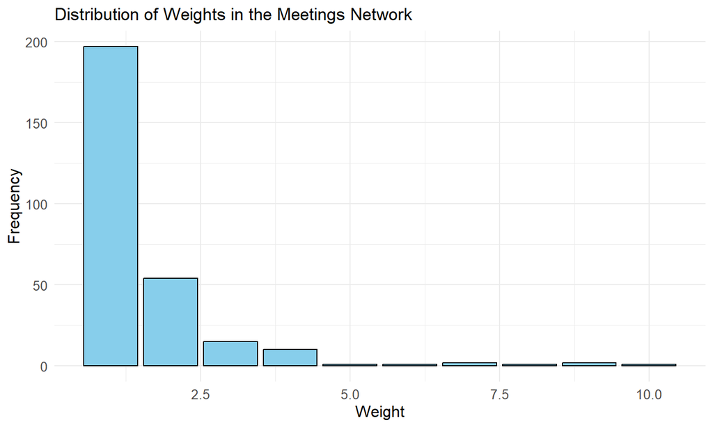

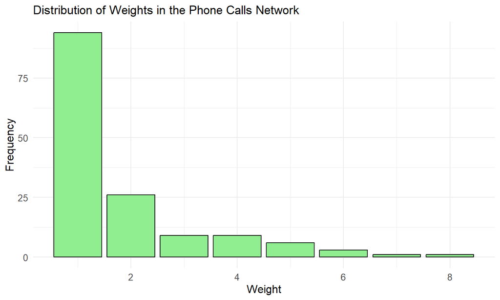

- La rete segue una distribuzione esponenziale: pochi nodi con archi molto pesanti e molti nodi con poche connessioni
- Le reti scale-free sono resistenti alla rimozione casuale di nodi, ma vulnerabili alla perdita degli hub
- Nella rete degli incontri, ci sono più nodi con pochi collegamenti rispetto alla rete delle telefonate (quasi il doppio)
- Il peso massimo della rete degli incontri è 10, suggerendo che i mafiosi preferiscono incontri fisici per ridurre il rischio di intercettazioni (più semplice criptare le conversazioni e usare il linguaggio del corpo)
- I nodi con grado più alto hanno ruolo di leadership, questo collega il fatto che spesso i capo-clan partecipano a eventi per confermare il loro potere e trasmettere messaggi ai subordinati

## Chi ha il ruolo di “collegamento” nella rete?

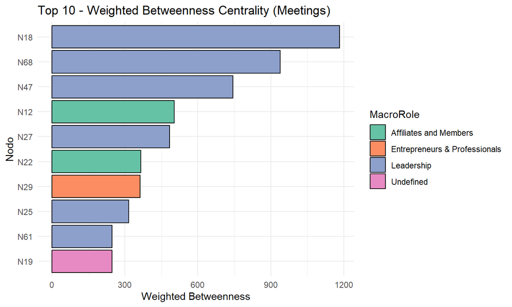

```
## # A tibble: 10 × 4
##    name  Role                              MacroRole                 betweenness
##    <chr> <chr>                             <chr>                           <dbl>
##  1 N18   "executive family ''Mistretta''"  Leadership                      1183.
##  2 N68   "executive family ''Batanesi''"   Leadership                       938.
##  3 N47   "deputy boss family ''Batanesi''" Leadership                       743.
##  4 N12   "member family ''Mistretta''"     Affiliates and Members           502.
##  5 N27   "executive family ''Batanesi''"   Leadership                       483.
##  6 N22   "Pharmacist-member"               Affiliates and Members           365.
##  7 N29   "enterpreneur"                    Entrepreneurs & Professi…        362.
##  8 N25   "executive family ''Mistretta''"  Leadership                       316.
##  9 N61   "executive family ''Mistretta''"  Leadership                       247.
## 10 N19   ""                                Undefined                        247.
```

Non è stato utilizzato il peso degli archi nel calcolo della betweenness centrality, poiché sarebbe stato interpretato come una distanza anziché come una frequenza dei collegamenti, modificando così l’interpretazione dei dati.

- I nodi di leadership (N18, N68, N47) sono i più centrali nella rete, con valori elevati di betweenness
- Il nodo N18, che rappresenta un esponente di alto livello della famiglia Mistretta, ha il valore di betweenness più alto (1183.04). Seguito dai leader delle famiglie Batanesi
- In secondo piano i membri e gli imprenditori (N22, N29) giocano un ruolo importante nel connettere diversi livelli della rete (collegamento e specifiche aree della rete economica o professionale)

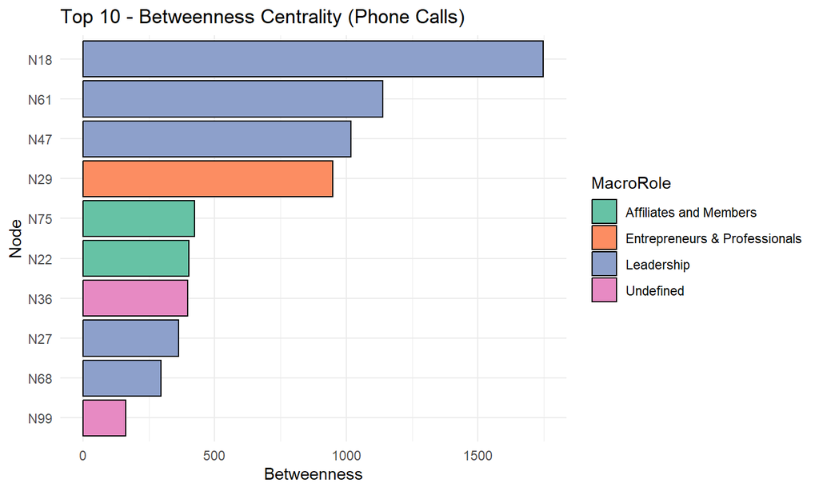

```
## # A tibble: 10 × 4
##    name  Role                              MacroRole                 betweenness
##    <chr> <chr>                             <chr>                           <dbl>
##  1 N18   "executive family ''Mistretta''"  Leadership                      1748.
##  2 N61   "executive family ''Mistretta''"  Leadership                      1138.
##  3 N47   "deputy boss family ''Batanesi''" Leadership                      1018.
##  4 N29   "enterpreneur"                    Entrepreneurs & Professi…        949.
##  5 N75   "member family ''Mistretta''"     Affiliates and Members           423.
##  6 N22   "Pharmacist-member"               Affiliates and Members           401.
##  7 N36   ""                                Undefined                        397.
##  8 N27   "executive family ''Batanesi''"   Leadership                       362.
##  9 N68   "executive family ''Batanesi''"   Leadership                       296.
## 10 N99   ""                                Undefined                        161
```

- I leader mafiosi restano i nodi più centrali nella rete delle telefonate
- N18 (fam. Mistretta) ha la betweenness più alta, seguito da N61 e N47 (vice-capo Batanesi)
- N29 (entrepreneur) mostra un’alta centralità, suggerendo un ruolo chiave nel collegamento tra la sfera criminale e il mondo economico.
- N22 (pharmacist-member) e N75 (Mistretta) agiscono come intermediari nella rete

Tuttavia, nella rete delle telefonate, emergono figure meno visibili ma strategiche, come N29 (entrepreneur) e N22 (pharmacist-member), con valori di betweenness più alti rispetto alla rete degli incontri.  
Questo potrebbe indicare che le telefonate vengono utilizzate per facilitare la comunicazione tra affiliati con ruoli più diversificati e per gestire aspetti operativi ed economici della rete mafiosa.

## Chi può diffondere le informazioni più rapidamente all’interno della rete?

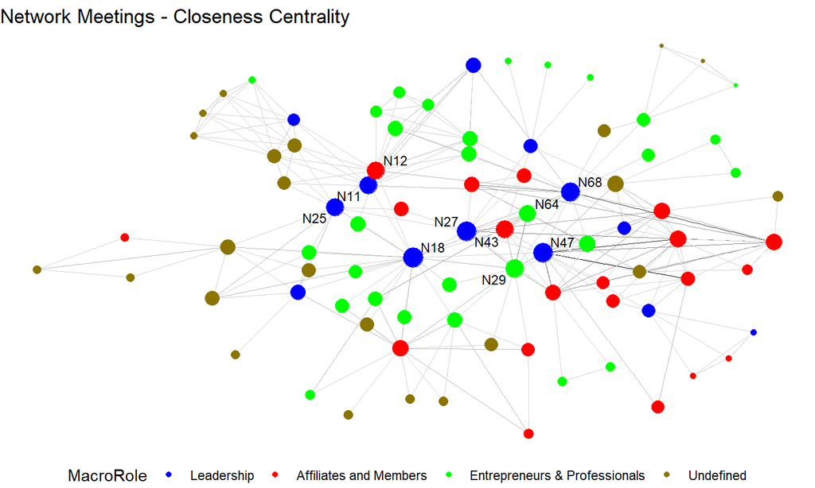

```
## # A tibble: 10 × 4
##    name  Role                            MacroRole                     closeness
##    <chr> <chr>                           <chr>                             <dbl>
##  1 N18   executive family ''Mistretta''  Leadership                      0.00585
##  2 N27   executive family ''Batanesi''   Leadership                      0.00559
##  3 N47   deputy boss family ''Batanesi'' Leadership                      0.00556
##  4 N68   executive family ''Batanesi''   Leadership                      0.00552
##  5 N29   enterpreneur                    Entrepreneurs & Professionals   0.00535
##  6 N43   intermediator                   Affiliates and Members          0.00515
##  7 N12   member family ''Mistretta''     Affiliates and Members          0.00513
##  8 N11   boss Cosa Nostra in Messina     Leadership                      0.00503
##  9 N25   executive family ''Mistretta''  Leadership                      0.00503
## 10 N64   enterpreneur                    Entrepreneurs & Professionals   0.00476
```

È stata considerata solo la componente gigante perché la closeness centrality si basa sulle distanze tra i nodi e ha senso calcolarla solo tra nodi che possono effettivamente raggiungersi. Le componenti più piccole avrebbero potuto falsare l’interpretazione.  
Inoltre anche per questa misura si è preferito non considerare il peso sugli archi perché sarebbe stato interpretato nella misura come distanza e non come frequenza.

- I leader delle famiglie Mistretta e Batanesi hanno la maggiore closeness centrality, facilitando la comunicazione nella rete
- Gli imprenditori (N29 e N64) collegano la rete criminale con il mondo economico
- N43 e alcuni affiliati fungono da snodi essenziali nella comunicazione interna
- Si nota come il Boss di Cosa Nostra a Messina (N11) abbia un ruolo rilevante nell’accesso alle informazioni. Questo suggerisce che la rete non sia limitata a una singola area geografica, ma abbia connessioni più ampie.

Il boss di Cosa Nostra a Messina (N11) non ha valori elevati di degree o betweenness centrality: non mantiene molte connessioni dirette né funge da ponte. Tuttavia, il suo alto valore di closeness centrality indica una posizione strategica per raggiungere rapidamente l’intera rete.

Questo potrebbe riflettere un modello tipico delle organizzazioni mafiose, dove i boss tendono a mantenere un profilo basso per ridurre il rischio di essere intercettati, delegando la gestione operativa a intermediari fidati. Il loro potere non deriva dalla quantità di connessioni dirette, ma dalla capacità di accedere rapidamente alle informazioni e influenzare la rete senza essere un punto di snodo evidente.

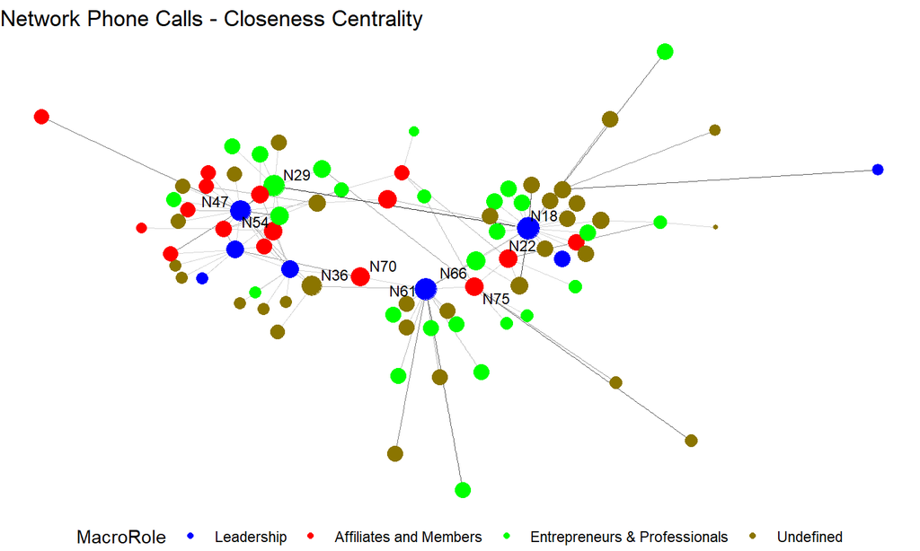

```
## # A tibble: 10 × 4
##    name  Role                              MacroRole                   closeness
##    <chr> <chr>                             <chr>                           <dbl>
##  1 N18   "executive family ''Mistretta''"  Leadership                    0.00562
##  2 N61   "executive family ''Mistretta''"  Leadership                    0.00538
##  3 N29   "enterpreneur"                    Entrepreneurs & Profession…   0.00526
##  4 N47   "deputy boss family ''Batanesi''" Leadership                    0.00495
##  5 N36   ""                                Undefined                     0.00474
##  6 N70   "member family ''Batanesi''"      Affiliates and Members        0.00450
##  7 N66   "enterpreneur"                    Entrepreneurs & Profession…   0.00439
##  8 N22   "Pharmacist-member"               Affiliates and Members        0.00433
##  9 N54   "enterpreneur"                    Entrepreneurs & Profession…   0.00433
## 10 N75   "member family ''Mistretta''"     Affiliates and Members        0.00429
```

- N18 e N61 (famiglia Mistretta) hanno i valori di closeness più alti, suggerendo un ruolo chiave nella diffusione delle informazioni
- N29 rappresenta una posizione strategica al terzo posto, collegando diversi membri della rete
- La presenza tra i nodi centrali di imprenditori e professionisti, evidenzia il ruolo cruciale delle figure economiche nel flusso di informazioni
- La rete delle telefonate potrebbe riflette un flusso di informazioni legato a gestione affari e coordinamento, con ruoli economici e operativi prominenti

Le telefonate servono a coordinare l’attività quotidiana e il flusso di informazioni in modo rapido ed efficiente, gli incontri sono probabilmente utilizzati per consolidare alleanze, discutere piani importanti e gestire relazioni più intime o delicate, con una maggiore partecipazione delle figure apicali della rete.

Questi risultati indicano che la struttura mafiosa è progettata per garantire una comunicazione efficiente tra i vari livelli dell’organizzazione, con una combinazione di leader, intermediari e figure economiche in posizioni strategiche.

## I nodi con molte connessioni sono sempre i più influenti, anche considerando i nodi a cui sono collegati?

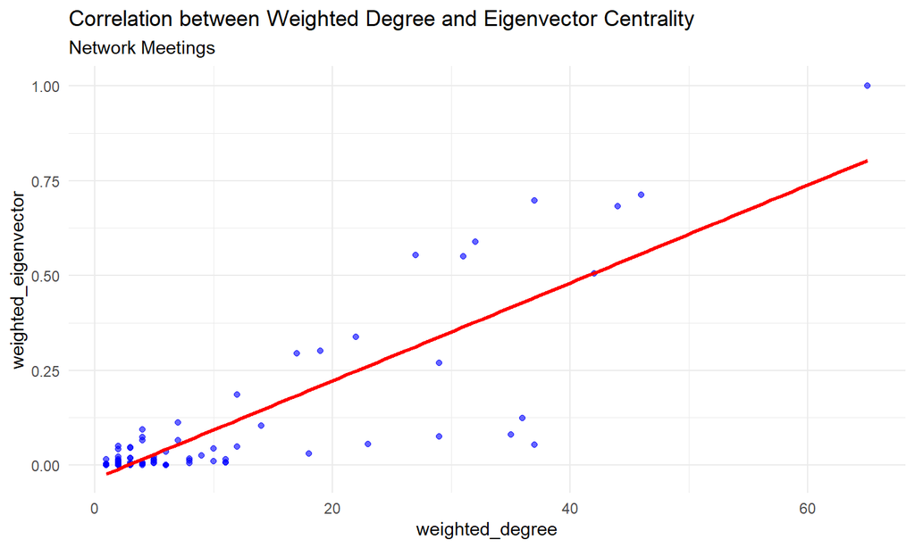

- La correlazione del valore di 0.741229 nella rete degli incontri suggerisce che chi ha molte connessioni è anche centrale ed importante
- I nodi con un alto grado hanno anche connessioni con individui strategici
- La rete appare altamente gerarchica, con pochi nodi centrali che influenzano la diffusione delle informazioni

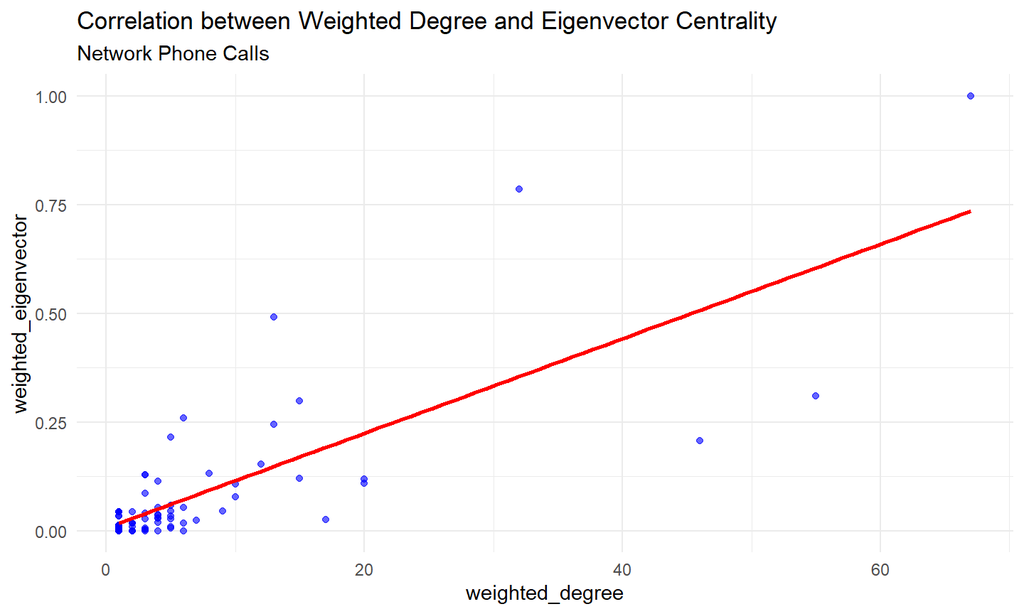

- La correlazione nella rete delle telefonate è di 0.5730693
- Il legame tra weighted degree ed eigenvector centrality è meno forte rispetto alla rete degli incontri
- Le connessioni nella rete delle telefonate risultano più distribuite e meno centralizzate attorno a pochi nodi chiave, con una maggiore eterogeneità nei ruoli

## Le reti degli incontri e delle telefonate seguono le stesse dinamiche comunicative o rispondono a esigenze diverse?

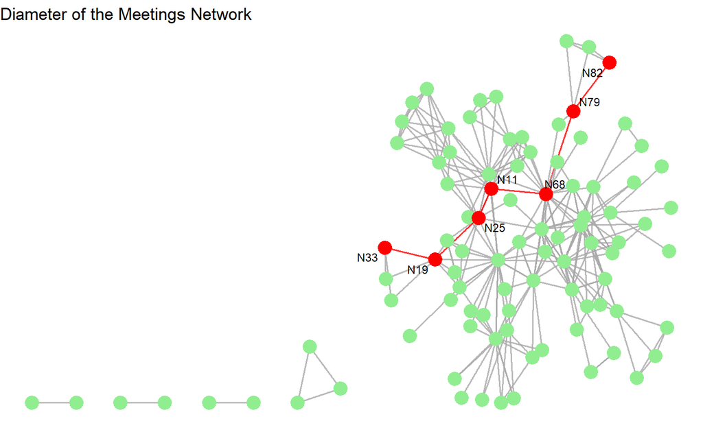

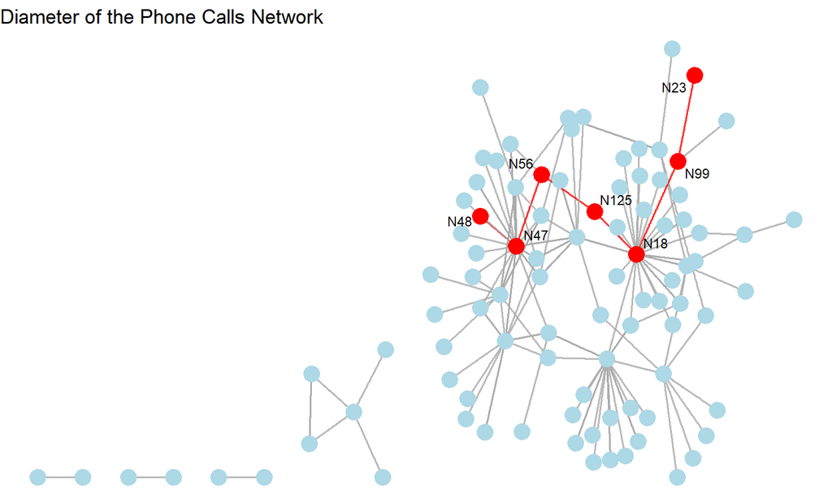

## Come varia la distribuzione delle lunghezze dei percorsi più brevi all’interno della rete?

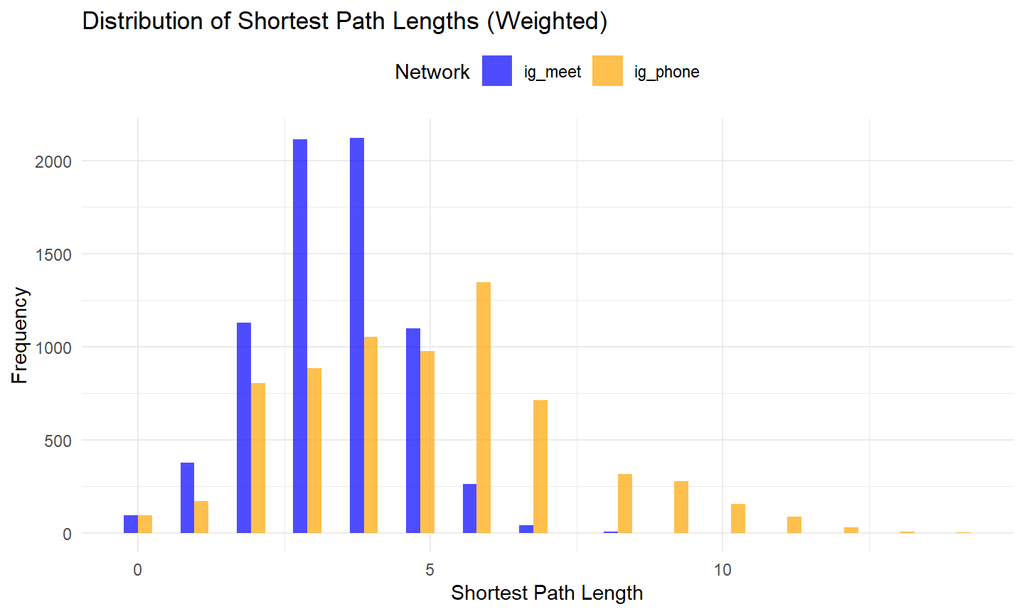

- La distribuzione della rete degli incontri è concentrata su cammini più brevi, indicano una comunicazione rapida ed efficiente
- La distribuzione della rete delle teelfonate è più ampia, con cammini più lunghi, suggerendo una comunicazione dispersa e meno diretta
- L’assenza di cammini troppo corti o troppo lunghi in entrambe le reti favorisce interazioni tra affiliati in posizioni intermedie per evitare rischi (sovraesposizione o intercettazioni)
- Una minore frequenza di interazioni nelle chiamate telefoniche rispetto agli incontri fa si che il clan cerchi di ridurre il rischio di intercettazioni, proteggendo i membri di rango più alto

## Quali sono i nodi in comune?

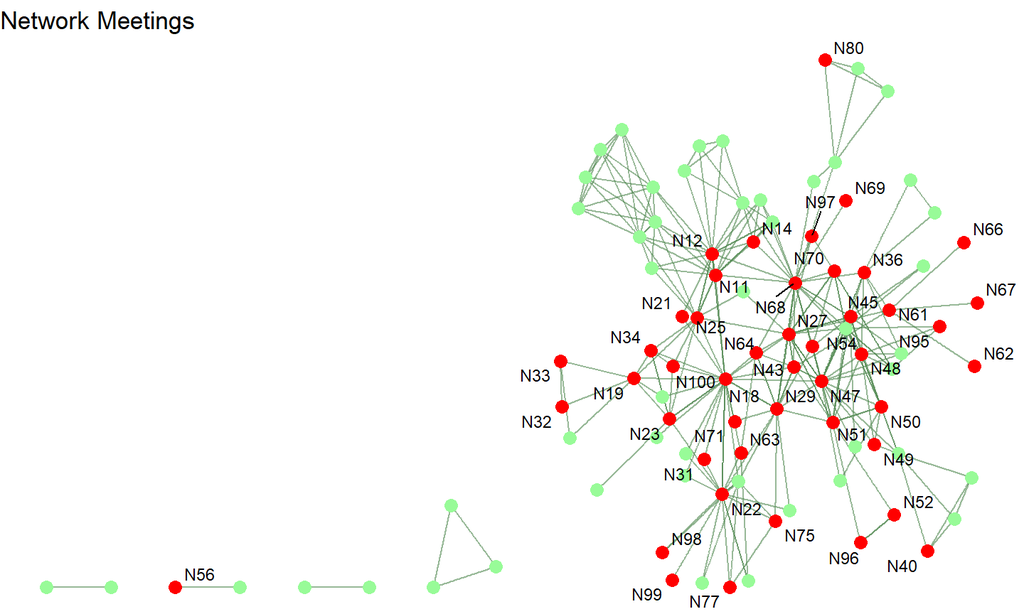

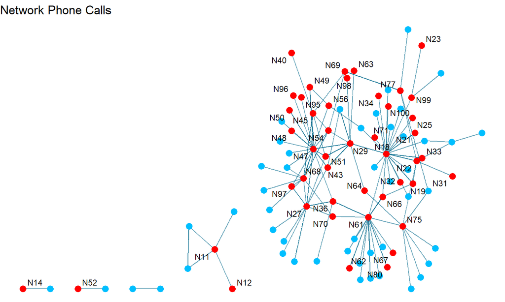

Si nota come la maggior parte dei nodi, in entrambe le reti siano centrali alla componente connessa gigante.

## Quali macro-ruoli sono più frequentemente soggetti ad arresto tra i nodi in comune?

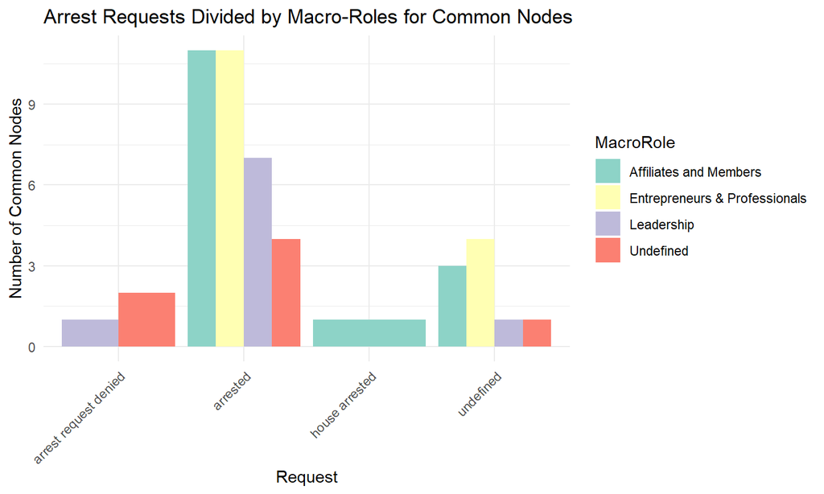

```
## # A tibble: 6 × 5
##   name  Request  Role                            MacroRole  weighted_degree
##   <chr> <chr>    <chr>                           <chr>                <dbl>
## 1 N47   arrested deputy boss family ''Batanesi'' Leadership              65
## 2 N27   arrested executive family ''Batanesi''   Leadership              44
## 3 N68   arrested executive family ''Batanesi''   Leadership              42
## 4 N18   arrested executive family ''Mistretta''  Leadership              36
## 5 N25   arrested executive family ''Mistretta''  Leadership              23
## 6 N23   arrested executive family                Leadership              11
```

```
## # A tibble: 6 × 5
##   name  Request  Role                        MacroRole           weighted_degree
##   <chr> <chr>    <chr>                       <chr>                         <dbl>
## 1 N22   arrested Pharmacist-member           Affiliates and Mem…              37
## 2 N45   arrested member family ''Batanesi''  Affiliates and Mem…              37
## 3 N12   arrested member family ''Mistretta'' Affiliates and Mem…              35
## 4 N51   arrested member family ''Batanesi''  Affiliates and Mem…              32
## 5 N48   arrested member family ''Batanesi''  Affiliates and Mem…              31
## 6 N50   arrested member family ''Batanesi''  Affiliates and Mem…              27
```

- La maggior parte degli arresti riguarda i ruoli di membri e affiliati e imprenditori
- Gli individui arrestati sono anche i nodi più importanti rappresentati nelle visualizzazioni precedenti
- Anche il nodo N22 rientra tra gli individui arrestati. Questo conferma la sua vicinanza alle attività mafiose

## Quale metrica è più efficace nel disgregare la rete?

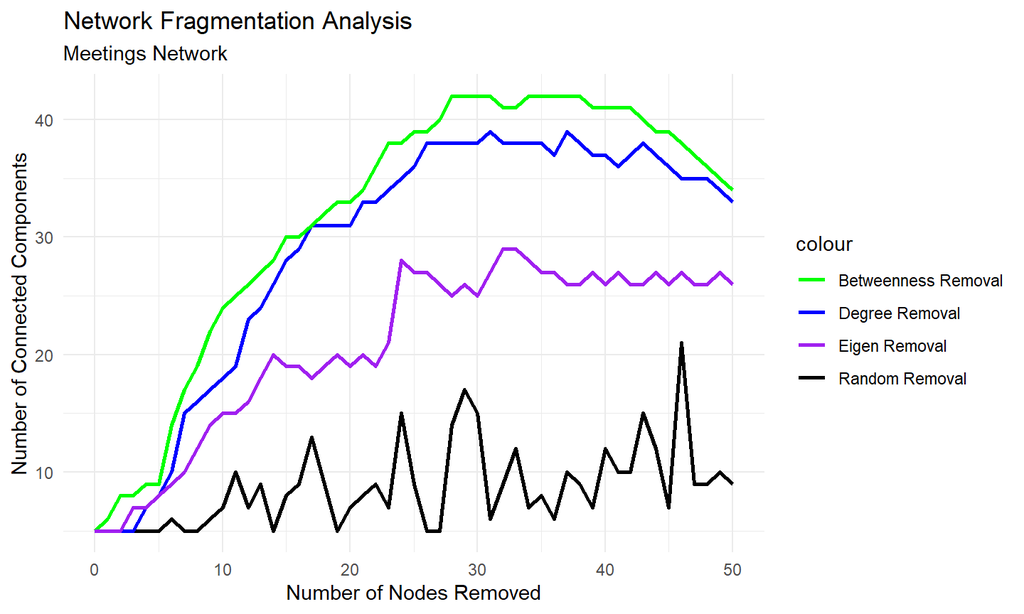

- La strategia migliore è la scelta della metrica betweenness
- Ottima anche la scelta di rimozione dei nodi in base al grado
- La rimozione casuale non ottiene buoni risultati. Questo conferma che la rete non ha una struttura casuale

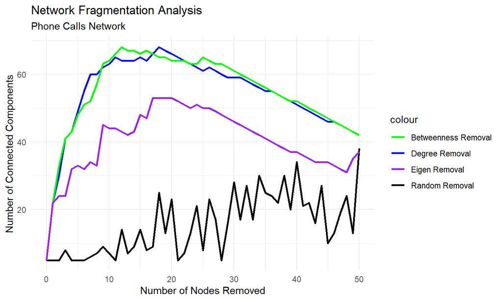

- La frammentazione è più rapida rispetto alla rete degli incontri poichè la rete delle telefonate è meno coesa e più dipendente da un numero limitato di nodi chiave
- Si possono rimuovere fino a circa 20 nodi scegliendo qualsiasi metrica ad eccezione della rimozione casuale
- Fino a 40 nodi rimossi si ottengono gli stessi risultati utilizzando sia la metrica betweenness sia il grado. Poi La metrica betweenness sembra ottenere migliori risultati
- La rimzione casuale anche in questo caso non rappresenta una strategia efficace

## Conclusioni

- L’analisi delle reti di incontri e telefonate evidenzia una struttura gerarchica, con i nodi centrali (leader e affiliati) essenziali per la diffusione delle informazioni e la coesione della rete mafiosa.
- La rete degli incontri è più compatta e diretta, favorendo comunicazioni rapide e sicure, mentre la rete delle telefonate è più dispersa e selettiva, probabilmente per evitare intercettazioni.
- Le telefonate facilitano il coordinamento delle attività quotidiane e il rapido scambio di informazioni, mentre gli incontri servono probabilmente a rafforzare alleanze, discutere strategie cruciali e gestire relazioni riservate, coinvolgendo maggiormente le figure di vertice della rete.
- I nodi chiave, come i leader e gli imprenditori, sono centrali nella rete, mentre figure come il farmacista e gli intermediari collegano il mondo criminale a quello legale.
- La rimozione di nodi chiave causa la rapida frammentazione della rete, indicando una struttura non casuale e dipendente da pochi hub centrali per il coordinamento.
- In sintesi, entrambe le reti mostrano un equilibrio tra efficienza comunicativa e sicurezza, con i nodi chiave vulnerabili al rischio di arresto.

> **“La lotta alla mafia dev’essere innanzitutto un movimento culturale che abitui tutti a sentire la bellezza del fresco profumo della libertà che si oppone al puzzo del compromesso morale, dell’indifferenza, della contiguità e quindi della complicità.”**  
> — *Paolo Borsellino*

Grazie per l’attenzione.

Susanna Micoli